# IODS course project

Erik Stahl

# About the project

The Introduction to Open Data Science introduces students to the ever-expanding world of data and open data sets. With an emphasis on open-source regarding the software and the data, the research is conducted transparently and thus reproducible by anyone, anywhere. [Here](https://github.com/ehstahl/IODS-project) is a link to my Github repository for the course work.

## #Week 2: Regression analysis

```r
s14 <- read.table(
  "http://s3.amazonaws.com/assets.datacamp.com/production/course_2218/datasets/learning2014.txt",
  sep=",",
  header=TRUE)
dim(s14)
```

```
## [1] 166   7
```

```r
str(s14)
```

```
## 'data.frame':    166 obs. of  7 variables:
##  $ gender  : Factor w/ 2 levels "F","M": 1 2 1 2 2 1 2 1 2 1 ...
##  $ age     : int  53 55 49 53 49 38 50 37 37 42 ...
##  $ attitude: num  3.7 3.1 2.5 3.5 3.7 3.8 3.5 2.9 3.8 2.1 ...
##  $ deep    : num  3.58 2.92 3.5 3.5 3.67 ...
##  $ stra    : num  3.38 2.75 3.62 3.12 3.62 ...
##  $ surf    : num  2.58 3.17 2.25 2.25 2.83 ...
##  $ points  : int  25 12 24 10 22 21 21 31 24 26 ...
```

Reads in the table from the assigned address. The dimensions function shows that the table has 166 observations and 7 variables. The structure function shows that the table has variables such as gender, age, attitude and points. The variables deep, stra and surf relate to questions regarding thinking on a deep, a strategic and a surface level. The structure also shows what kind of data type is used in each variable.

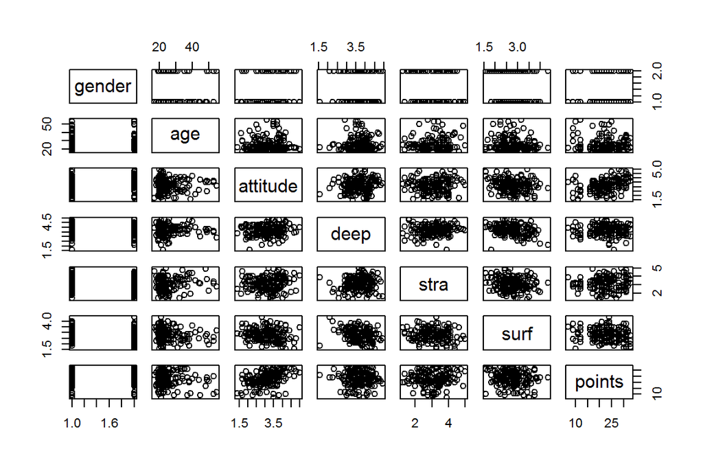

```r
plot(s14)
```

This basic plotting function renders a scatterplot overview of all the variables in the table and how the observations land on them. On the upside this gives an overview, but at the same time it’s hard to draw any conclusions from this. This can perhaps mainly be used to get hints at what to have a closer look at.

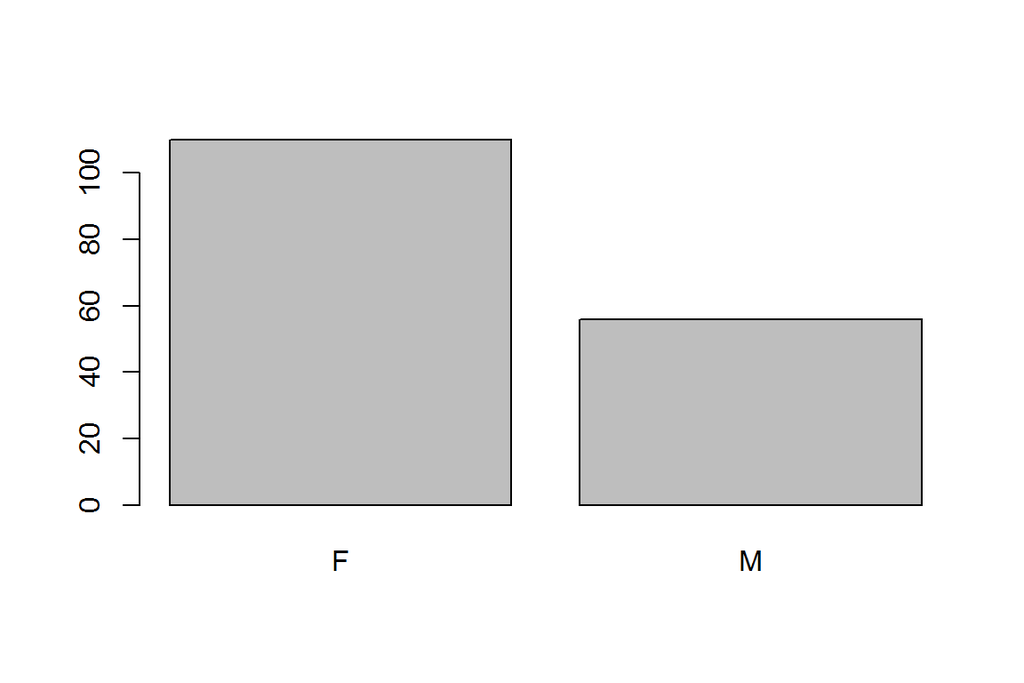

```r
plot(s14$gender)
```

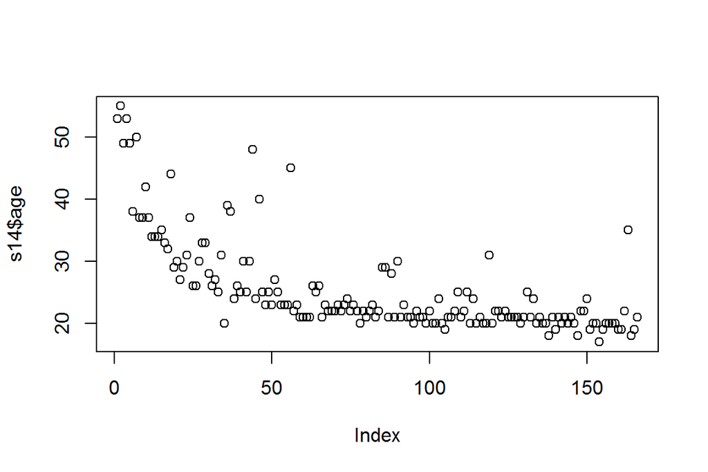

```r
plot(s14$age)
```

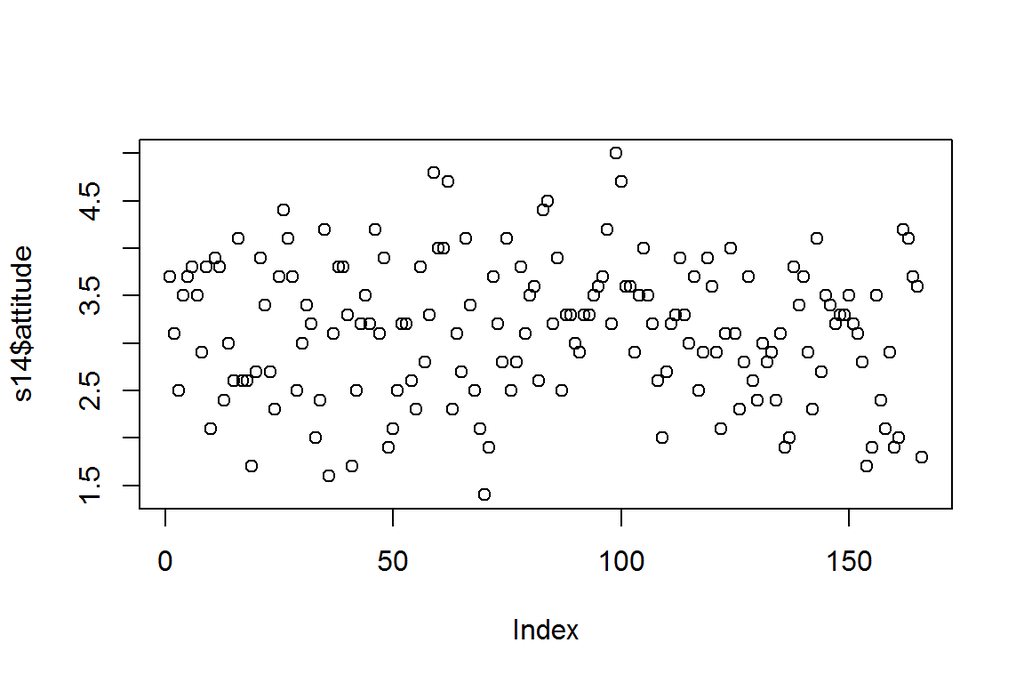

```r
plot(s14$attitude)
```

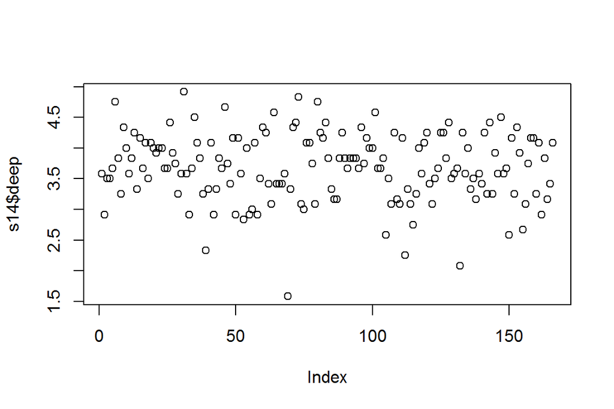

```r
plot(s14$deep)
```

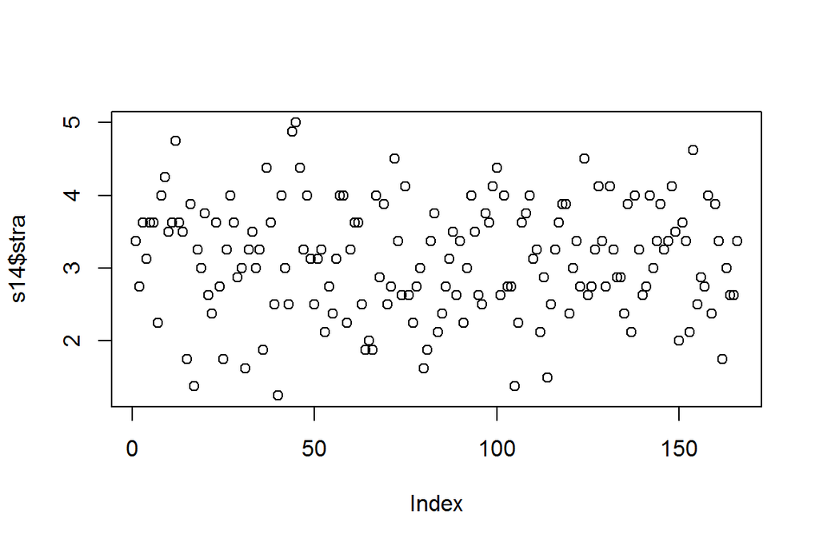

```r
plot(s14$stra)
```

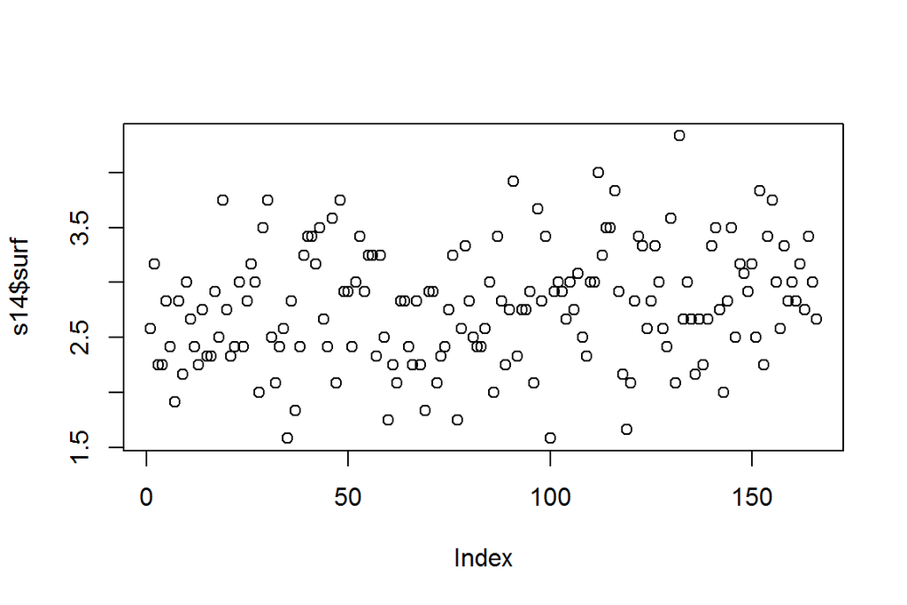

```r
plot(s14$surf)
```

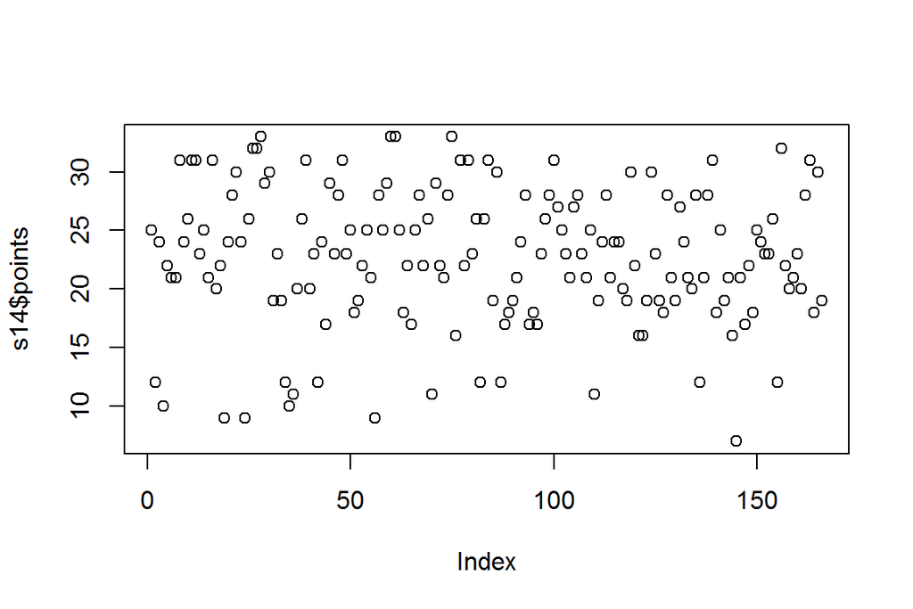

```r
plot(s14$points)
```

The separate plots show how the observations (166 individuals) are distributed across each variable. The first one (gender) shows that there are about half as many men in this table as there are women. The second one shows a scatterplot, which illustrates that over 2/3 of the individuals are younger than 30 years. The last one shows that well over half of the participants scored over 20 points.

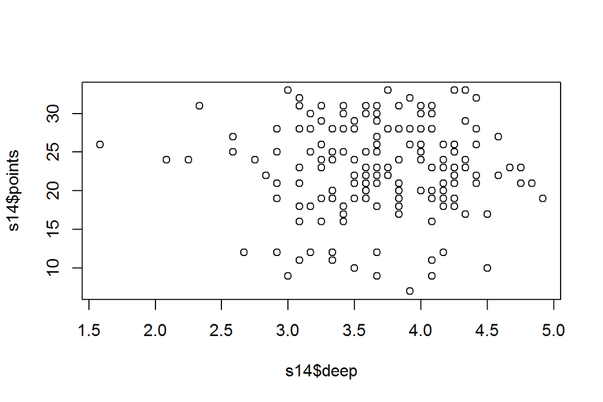

```r
plot(s14$deep, s14$points)
```

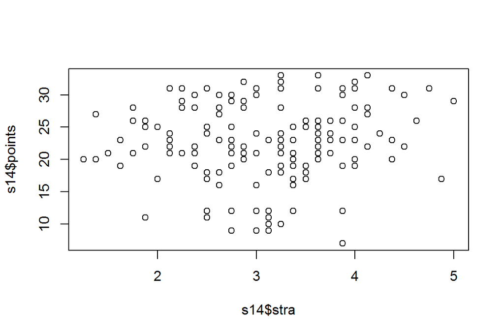

```r
plot(s14$stra, s14$points)
```

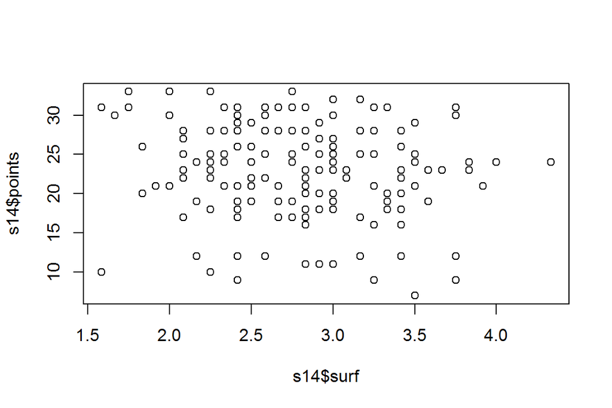

```r
plot(s14$surf, s14$points)
```

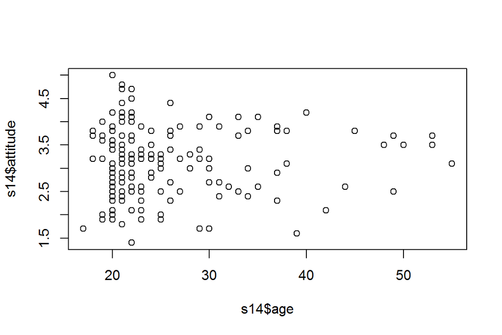

```r
plot(s14$age, s14$attitude)
```

```r
malli <- lm(points ~ attitude + age + stra, data = s14)
summary(malli)
```

```
##
## Call:
## lm(formula = points ~ attitude + age + stra, data = s14)
##
## Residuals:
##      Min       1Q   Median       3Q      Max
## -18.1149  -3.2003   0.3303   3.4129  10.7599
##
## Coefficients:
##             Estimate Std. Error t value Pr(>|t|)
## (Intercept) 10.89543    2.64834   4.114 6.17e-05 ***
## attitude     3.48077    0.56220   6.191 4.72e-09 ***
## age         -0.08822    0.05302  -1.664   0.0981 .
## stra         1.00371    0.53434   1.878   0.0621 .
## ---
## Signif. codes:  0 '***' 0.001 '**' 0.01 '*' 0.05 '.' 0.1 ' ' 1
##
## Residual standard error: 5.26 on 162 degrees of freedom
## Multiple R-squared:  0.2182, Adjusted R-squared:  0.2037
## F-statistic: 15.07 on 3 and 162 DF,  p-value: 1.07e-08
```

Above we have rendered a regression model with the variable points as the dependent variable (y-axis in a plot) and the variables attitude, age and stra (strategic thinking) as explanatory variables (x-axis in a plot). The function summary returns a summary of this model.

The variables age and stra have weaker statistical significance, while attitude has the clearly strongest significance. Combined, the explanatory variables however draw a p-value far below 0.05. It should however be noted that both the age and the stra variable have p-values larger than 0.05, so this raises some serious questions if we dare accept the hypothesis of the model (that there is a relation between the dependent and the explanatories) in this case. To be absolutely sure, I would prefer having explanatory variables which all provide p-values below 0.05 to confidently reject the null hypothesis for the whole model, that is confirm that a relation exists between the points variable and these three variables combined.

The residual standard error is 5.26. That means that this is the average difference between the y-value (points) of the regression line of the model and the actual observed y-value of a given observation. In other words the regression line is on average off by over 5 points. On a scale of max 33 points, that is quite a lot. Moving on to the multiple R-squared result, that doesn’t give much reason for joy either. The given figure is 0.2182, rounded to a percentage: 22 percent. This means that just under 22 percent of variation in amount of points can be explained by the explanatory variables in our model (attitude, age and strategic thinking).

**Didn’t have time to do the fifth part with the diagnostic plots**

## #Week 3: Logistic regression

Start off by importing the dataframe and examining it.

```r
joined <- read.table("http://s3.amazonaws.com/assets.datacamp.com/production/course_2218/datasets/alc.txt",
                     sep = ",",
                     header = TRUE)

dim(joined)
```

```
## [1] 382  35
```

```r
colnames(joined)
```

```
##  [1] "school"     "sex"        "age"        "address"    "famsize"
##  [6] "Pstatus"    "Medu"       "Fedu"       "Mjob"       "Fjob"
## [11] "reason"     "nursery"    "internet"   "guardian"   "traveltime"
## [16] "studytime"  "failures"   "schoolsup"  "famsup"     "paid"
## [21] "activities" "higher"     "romantic"   "famrel"     "freetime"
## [26] "goout"      "Dalc"       "Walc"       "health"     "absences"
## [31] "G1"         "G2"         "G3"         "alc_use"    "high_use"
```

This data set includes 382 observations, in this case students, and spans 35 variables, all of which you can see in the output above. The topic of the data is student achievement in secondary education of two Portuguese schools. The data was collected by using school reports and questionnaires. Originally the set consists of two sets, one on performance in mathematics and one in Portuguese language. In this set (joined) these two sets have been joined together. Most of the variables provides background about the student. The variables G1, G2 and G3 give the average math and Portuguese grade in the first, second period and the final grade respectively. Two new variables have also been created in the joined dataset. One (alc_use) gives an average alcohol consumption for a student, and the other column (high_use) returns “TRUE” if this figure is above 2.

To analyze the possible high alcohol use, I take a “marginalized youth” approach. The variables I use are absences, free time, failures and age. For the first three my hypothesis is that the higher the absences and failures, the higher the alcohol use could be. “Too much” free time could also be a contributing factor. For age I don’t have an equally clear cut assumption. Perhaps the use among younger (15-year-olds) could be higher than among the older students (22-year-olds).

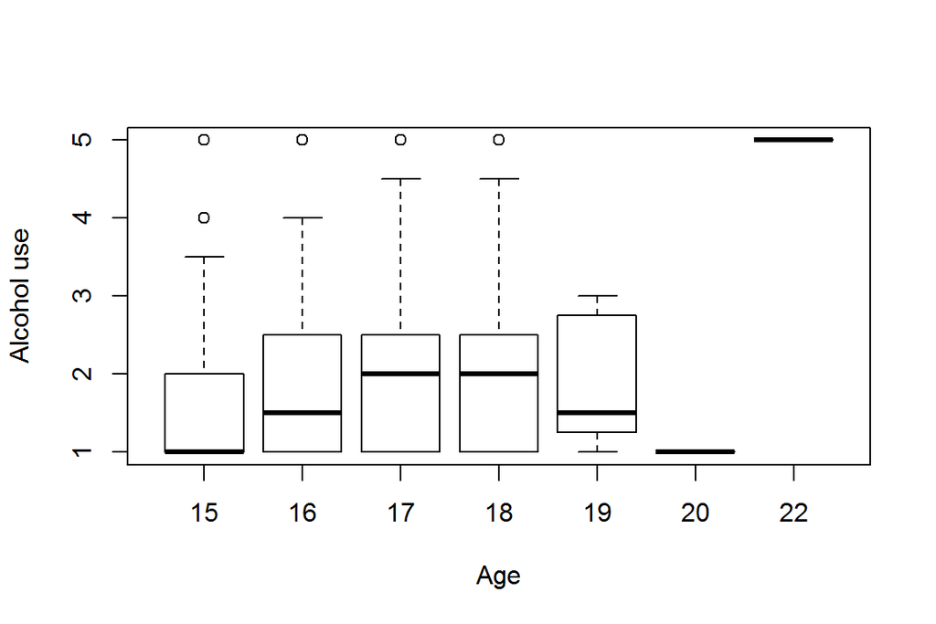

```r
boxplot(joined$alc_use ~ joined$age, ylab="Alcohol use", xlab="Age")
```

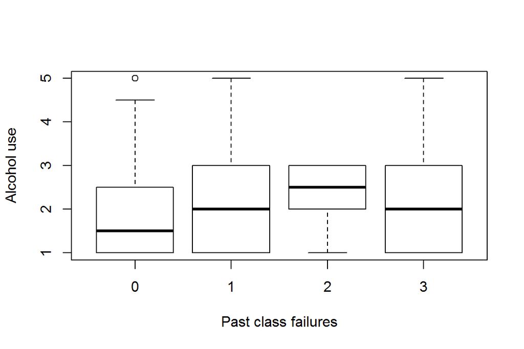

```r
boxplot(joined$alc_use ~ joined$failures, ylab="Alcohol use", xlab="Past class failures")
```

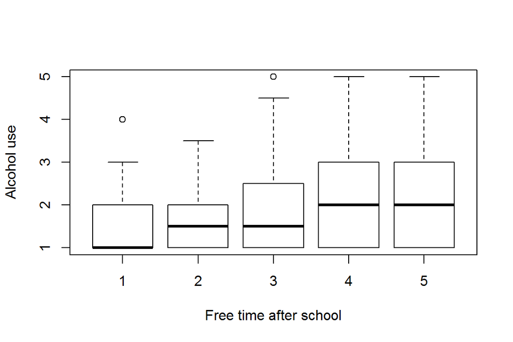

```r
boxplot(joined$alc_use ~ joined$freetime, ylab="Alcohol use", xlab="Free time after school")
```

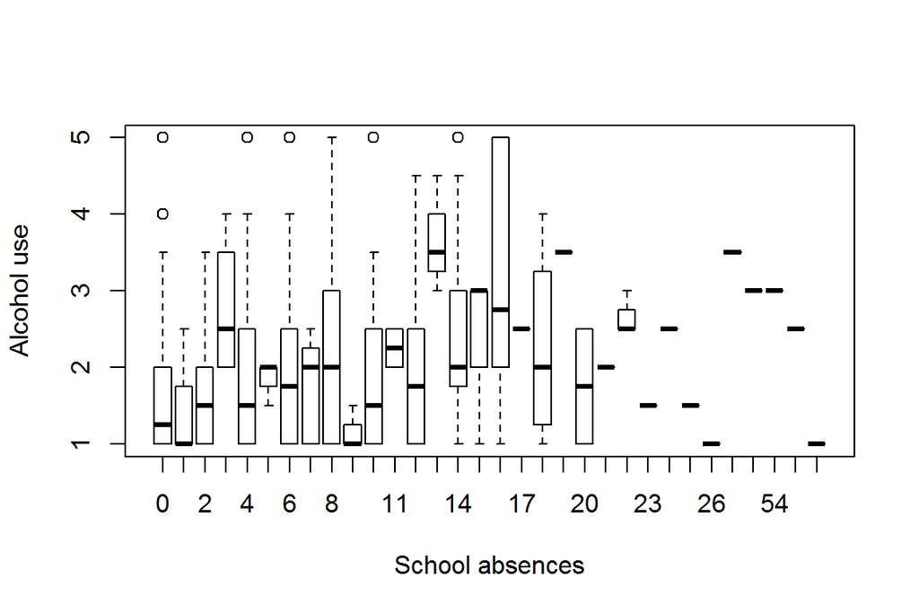

```r
boxplot(joined$alc_use ~ joined$absences, ylab="Alcohol use", xlab="School absences")
```

As the box plots show, all of my hypotheses were wrong. No obvious trends are visible to support them. For age, the distribution resembles a nice bell curve, but the increase in the middle age range is quite modest. Past class failures doesn’t either serve as a good indicator for higher alcohol use. The free time after school actually shows a positive correlation with alcohol use, but that too is quite moderate. With absences there are some individuals with quite high alcohol use around the middle range (13 absences), but on the whole there is no apparent trend.

```r
cor(joined[c(34,3,17,25,30)])
```

```
##            alc_use         age   failures     freetime    absences
## alc_use  1.0000000 0.156382087 0.14992078  0.177353585  0.20229589
## age      0.1563821 1.000000000 0.15303314  0.004882109  0.12597150
## failures 0.1499208 0.153033139 1.00000000  0.092117126  0.01724612
## freetime 0.1773536 0.004882109 0.09211713  1.000000000 -0.04881396
## absences 0.2022959 0.125971504 0.01724612 -0.048813959  1.00000000
```

The correlation table backs up the box plots, showing no remarkable correlation figures between alcohol use and the used variables.

Moving on to the logistic regression, we create a generalized linear model.

```r
malli <- glm(high_use~age+failures+freetime+absences, data = joined, binomial())

summary.glm(malli)
```

```
##
## Call:
## glm(formula = high_use ~ age + failures + freetime + absences,
##     family = binomial(), data = joined)
##
## Deviance Residuals:
##     Min       1Q   Median       3Q      Max
## -2.4505  -0.8100  -0.6528   1.1211   2.0172
##
## Coefficients:
##             Estimate Std. Error z value Pr(>|z|)
## (Intercept) -4.49403    1.75703  -2.558 0.010536 *
## age          0.11597    0.10240   1.132 0.257431
## failures     0.35751    0.15164   2.358 0.018394 *
## freetime     0.36166    0.12349   2.929 0.003403 **
## absences     0.06662    0.01777   3.750 0.000177 ***
## ---
## Signif. codes:  0 '***' 0.001 '**' 0.01 '*' 0.05 '.' 0.1 ' ' 1
##
## (Dispersion parameter for binomial family taken to be 1)
##
##     Null deviance: 462.21  on 381  degrees of freedom
## Residual deviance: 425.58  on 377  degrees of freedom
## AIC: 435.58
##
## Number of Fisher Scoring iterations: 4
```

Presenting the summary for this relationship, shows a stronger relationship than in the example above. This can primarily be explained by the bar in a way being “lowered”. When the target variable changed to “high_use”, the explanatory variables now have a different task: their role in explaining a student’s alcohol use being above 2. A glance at the summary shows that now for this task, both the freetime and absences variables are highly statistically significant. Which means we have solid reason to assume these variables do have an impact on the target variable in this case. The significance for failures is a bit weaker but still quite okay, but the age variable is not one to trust in this case. Therefore, we dump that variable and continue without it.

```r
malli <- glm(high_use~failures+freetime+absences, data = joined, binomial())

summary.glm(malli)
```

```
##
## Call:
## glm(formula = high_use ~ failures + freetime + absences, family = binomial(),
##     data = joined)
##
## Deviance Residuals:
##     Min       1Q   Median       3Q      Max
## -2.4481  -0.7907  -0.6347   1.0983   2.0385
##
## Coefficients:
##             Estimate Std. Error z value Pr(>|z|)
## (Intercept) -2.57903    0.44820  -5.754 8.71e-09 ***
## failures     0.38120    0.14913   2.556  0.01059 *
## freetime     0.35970    0.12316   2.921  0.00349 **
## absences     0.06886    0.01780   3.868  0.00011 ***
## ---
## Signif. codes:  0 '***' 0.001 '**' 0.01 '*' 0.05 '.' 0.1 ' ' 1
##
## (Dispersion parameter for binomial family taken to be 1)
##
##     Null deviance: 462.21  on 381  degrees of freedom
## Residual deviance: 426.87  on 378  degrees of freedom
## AIC: 434.87
##
## Number of Fisher Scoring iterations: 4
```

The summary lists the explanatory variables and how they relate to the target variable, or more accurately to the high use of alcohol being true. In the leftmost column under “Estimate”, the figures show how much the log odds is estimated to increase if this specific variable (for example failures) would be increased by one unit. So if freetime was increased by one unit, it is estimated that the log odds of high alcohol use being true would increase by 0.359. Next we calculate the odds ratios for the coefficients and confidence intervals for them.

```r
exp(cbind(OR = coef(malli), confint(malli)))
```

```
##                     OR      2.5 %    97.5 %
## (Intercept) 0.07584731 0.03061813 0.1780763
## failures    1.46403397 1.09188878 1.9676275
## freetime    1.43290098 1.12949959 1.8323653
## absences    1.07128798 1.03702729 1.1115624
```

**Didn’t have time to finish exercies 6 and onwards.**

## #Week 4: Clustering and classification

Import the package MASS and the Boston data.

```r
library(MASS)
data("Boston")
class(Boston)
```

```
## [1] "data.frame"
```

```r
str(Boston)
```

```
## 'data.frame':    506 obs. of  14 variables:
##  $ crim   : num  0.00632 0.02731 0.02729 0.03237 0.06905 ...
##  $ zn     : num  18 0 0 0 0 0 12.5 12.5 12.5 12.5 ...
##  $ indus  : num  2.31 7.07 7.07 2.18 2.18 2.18 7.87 7.87 7.87 7.87 ...
##  $ chas   : int  0 0 0 0 0 0 0 0 0 0 ...
##  $ nox    : num  0.538 0.469 0.469 0.458 0.458 0.458 0.524 0.524 0.524 0.524 ...
##  $ rm     : num  6.58 6.42 7.18 7 7.15 ...
##  $ age    : num  65.2 78.9 61.1 45.8 54.2 58.7 66.6 96.1 100 85.9 ...
##  $ dis    : num  4.09 4.97 4.97 6.06 6.06 ...
##  $ rad    : int  1 2 2 3 3 3 5 5 5 5 ...
##  $ tax    : num  296 242 242 222 222 222 311 311 311 311 ...
##  $ ptratio: num  15.3 17.8 17.8 18.7 18.7 18.7 15.2 15.2 15.2 15.2 ...
##  $ black  : num  397 397 393 395 397 ...
##  $ lstat  : num  4.98 9.14 4.03 2.94 5.33 ...
##  $ medv   : num  24 21.6 34.7 33.4 36.2 28.7 22.9 27.1 16.5 18.9 ...
```

```r
dim(Boston)
```

```
## [1] 506  14
```

The Boston data is a dataframe, that has 506 observations and 14 columns.

The Boston data comprises of housing values in suburbs of Boston. That is, the observations are specific suburb areas and this data estimates that areas housing value based on 14 different variables, such as crime rate or pollution in the area.

All 14 variables are numeric, except “chas” and “rad” that are integers. “Chas” is just an indicator, returning a 1 if the area is connected to the Charles river and 0 if it’s not. “Rad” is an index for accessibility to radial highways. Runs from 1 through 24, as seen in the summaries. The rest of the variables are numeric and have widely ranging values. They comprise of median values (medv), pupil-teacher ratios (ptratio), average number of rooms per house (rm) etc. The summary of the variables illustrates this below.

```r
summary(Boston)
```

```
##       crim                zn             indus            chas
##  Min.   : 0.00632   Min.   :  0.00   Min.   : 0.46   Min.   :0.00000
##  1st Qu.: 0.08204   1st Qu.:  0.00   1st Qu.: 5.19   1st Qu.:0.00000
##  Median : 0.25651   Median :  0.00   Median : 9.69   Median :0.00000
##  Mean   : 3.61352   Mean   : 11.36   Mean   :11.14   Mean   :0.06917
##  3rd Qu.: 3.67708   3rd Qu.: 12.50   3rd Qu.:18.10   3rd Qu.:0.00000
##  Max.   :88.97620   Max.   :100.00   Max.   :27.74   Max.   :1.00000
##       nox               rm             age              dis
##  Min.   :0.3850   Min.   :3.561   Min.   :  2.90   Min.   : 1.130
##  1st Qu.:0.4490   1st Qu.:5.886   1st Qu.: 45.02   1st Qu.: 2.100
##  Median :0.5380   Median :6.208   Median : 77.50   Median : 3.207
##  Mean   :0.5547   Mean   :6.285   Mean   : 68.57   Mean   : 3.795
##  3rd Qu.:0.6240   3rd Qu.:6.623   3rd Qu.: 94.08   3rd Qu.: 5.188
##  Max.   :0.8710   Max.   :8.780   Max.   :100.00   Max.   :12.127
##       rad              tax           ptratio          black
##  Min.   : 1.000   Min.   :187.0   Min.   :12.60   Min.   :  0.32
##  1st Qu.: 4.000   1st Qu.:279.0   1st Qu.:17.40   1st Qu.:375.38
##  Median : 5.000   Median :330.0   Median :19.05   Median :391.44
##  Mean   : 9.549   Mean   :408.2   Mean   :18.46   Mean   :356.67
##  3rd Qu.:24.000   3rd Qu.:666.0   3rd Qu.:20.20   3rd Qu.:396.23
##  Max.   :24.000   Max.   :711.0   Max.   :22.00   Max.   :396.90
##      lstat            medv
##  Min.   : 1.73   Min.   : 5.00
##  1st Qu.: 6.95   1st Qu.:17.02
##  Median :11.36   Median :21.20
##  Mean   :12.65   Mean   :22.53
##  3rd Qu.:16.95   3rd Qu.:25.00
##  Max.   :37.97   Max.   :50.00
```

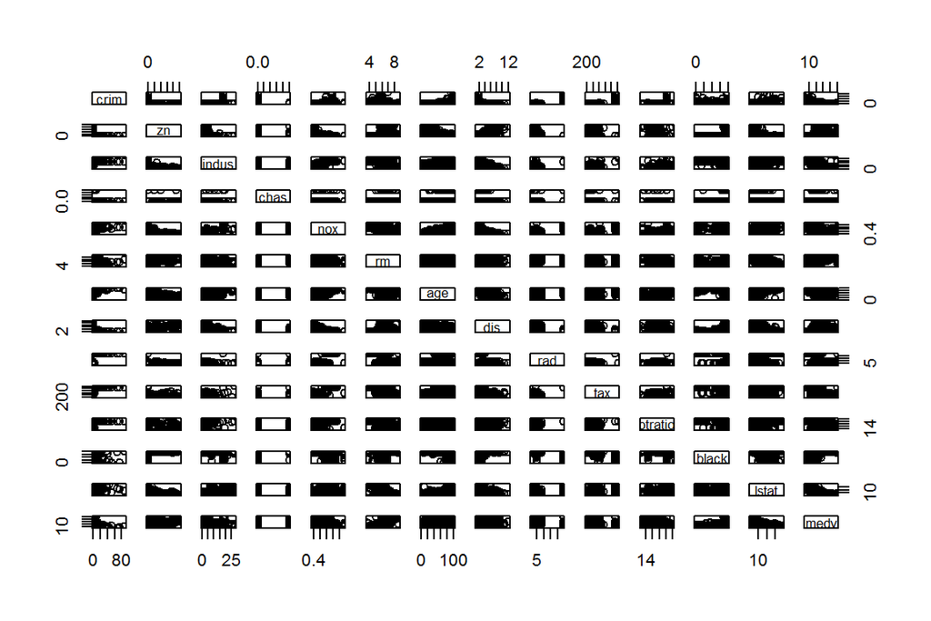

```r
pairs(Boston)
```

A huge table like this (14x14) is seldom useful for proper analysis, but some clear enough connections can be interpreted from this table.

Something that already jumps out in the summary of the variables is the distribution within the crime variable. The rate is quite moderate up until after the 3rd quartile where it spikes. So there are a few areas with a massively higher crime rate than the others. This can make for an interesting analysis object. And as we see in the table, for example a high rate of crime only occurs in areas with high pupils to student ratios.

Another peculiar combination is zoning (zn) and property-tax rate (tax). The zoning variable shows how large a proportion of residential land in the area is zoned for lots over 25 000 sq feet (about 2326 sq meters, could fit a very large one-family house) and the other variable gives the property tax rate in the area. Some areas with no large lots have sky high tax rates, but the rest of the observations all lie roughly within a coherent tax range (200-400). Raises suspicions that the zoning variable can identify wealthy areas (large houses on large lots) and that they have the same tax rate as poorer residents in other areas (that is, relatively much cheaper rates for the rich ones). Of course, large lots could also mean very large houses in the form of high rises and such. So my suspicion would need to be cross-checked with other variables, such as median value of homes (medv).

The distribution of the black variable is interesting, with a few observations below the first quartile being nearly completely all-white. But already at the first quartile the proportion is quite large of the total population, so I doubt there is a larger trend to be drawn from these largely non-black areas. Would of course be interesting to single out the few and have a closer look at them in general.

Moving on to scaling the data.

```r
b_scaled <- scale(Boston)

b_scaled <- as.data.frame(b_scaled)

summary(b_scaled)
```

```
##       crim                 zn               indus
##  Min.   :-0.419367   Min.   :-0.48724   Min.   :-1.5563
##  1st Qu.:-0.410563   1st Qu.:-0.48724   1st Qu.:-0.8668
##  Median :-0.390280   Median :-0.48724   Median :-0.2109
##  Mean   : 0.000000   Mean   : 0.00000   Mean   : 0.0000
##  3rd Qu.: 0.007389   3rd Qu.: 0.04872   3rd Qu.: 1.0150
##  Max.   : 9.924110   Max.   : 3.80047   Max.   : 2.4202
##       chas              nox                rm               age
##  Min.   :-0.2723   Min.   :-1.4644   Min.   :-3.8764   Min.   :-2.3331
##  1st Qu.:-0.2723   1st Qu.:-0.9121   1st Qu.:-0.5681   1st Qu.:-0.8366
##  Median :-0.2723   Median :-0.1441   Median :-0.1084   Median : 0.3171
##  Mean   : 0.0000   Mean   : 0.0000   Mean   : 0.0000   Mean   : 0.0000
##  3rd Qu.:-0.2723   3rd Qu.: 0.5981   3rd Qu.: 0.4823   3rd Qu.: 0.9059
##  Max.   : 3.6648   Max.   : 2.7296   Max.   : 3.5515   Max.   : 1.1164
##       dis               rad               tax             ptratio
##  Min.   :-1.2658   Min.   :-0.9819   Min.   :-1.3127   Min.   :-2.7047
##  1st Qu.:-0.8049   1st Qu.:-0.6373   1st Qu.:-0.7668   1st Qu.:-0.4876
##  Median :-0.2790   Median :-0.5225   Median :-0.4642   Median : 0.2746
##  Mean   : 0.0000   Mean   : 0.0000   Mean   : 0.0000   Mean   : 0.0000
##  3rd Qu.: 0.6617   3rd Qu.: 1.6596   3rd Qu.: 1.5294   3rd Qu.: 0.8058
##  Max.   : 3.9566   Max.   : 1.6596   Max.   : 1.7964   Max.   : 1.6372
##      black             lstat              medv
##  Min.   :-3.9033   Min.   :-1.5296   Min.   :-1.9063
##  1st Qu.: 0.2049   1st Qu.:-0.7986   1st Qu.:-0.5989
##  Median : 0.3808   Median :-0.1811   Median :-0.1449
##  Mean   : 0.0000   Mean   : 0.0000   Mean   : 0.0000
##  3rd Qu.: 0.4332   3rd Qu.: 0.6024   3rd Qu.: 0.2683
##  Max.   : 0.4406   Max.   : 3.5453   Max.   : 2.9865
```

The Boston data has now been standardized, subtracting the means from respective columns and dividing the result by the standard deviation. As the summary shows the mean in each variable is now 0 and the figures for the quartiles etc. have changed as well. All variables are now standardized and scaled to make comparing the different variables with each other easier. Next up: creating a categorical variable of the scaled crime rate.

```r
crimcat <- quantile(b_scaled$crim)

crime <- cut(b_scaled$crim, breaks = crimcat, include.lowest = TRUE, label = c("Low","Med_low","Med_high","High"))

b_scaled <- dplyr::select(b_scaled, -crim)

b_scaled <- data.frame(b_scaled, crime)
```

The old numeric crime variable has now been dropped from the dataset (second last line of code) and a new categorical crime variable has been lifted in. It is divided into four categories (Low to High) by quantiles. Next: splitting the set into training and test data.

```r
n <- nrow(b_scaled)

chosen <- sample(n, size=(n*0.8))

train <- b_scaled[chosen,]
test <- b_scaled[-chosen,]
```

Now the dataset is divided into two, with 80% of the data sitting in the ‘train’ set. Next we fit the ‘train’ set to a linear discriminant analysis model, using the categorical crime variable as target variable and all the others as predictor variables.

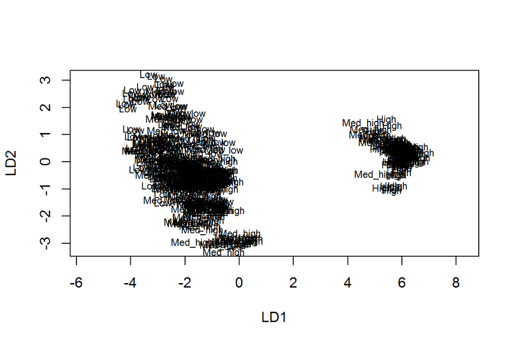

```r
lda.fit <- lda(crime ~ ., data = train)
plot(lda.fit, dimen = 2)
```

Next we grab the crime categories from the test set and then remove the categorical crime variable from the test dataset.

```r
c_classes <- test$crime

test <- dplyr::select(test,-crime)
```

Then we predict the classes with our LDA model on the test data.

```r
lda.pred <- predict(lda.fit, newdata = test)
```

And cross tabulate the results with the crime categories from the test set.

```r
tab = table(correct = c_classes, predicted = lda.pred$class)
addmargins(tab)
```

```
##           predicted
## correct    Low Med_low Med_high High Sum
##   Low       17       7        1    0  25
##   Med_low    5      19        4    0  28
##   Med_high   1       5       17    0  23
##   High       0       0        0   26  26
##   Sum       23      31       22   26 102
```

As we can see from the row and column sums, the model seems to predict fairly well. In the lower categories the prediction is slightly off, but the models seems to be able to predict the ‘high’ category quite well.

Next up: reload the Boston dataset, scale it and calculate the distances between the observations.

```r
library(MASS)
data(Boston)
b_scaled <- scale(Boston)
b_scaled <- as.data.frame(b_scaled)
dist_eu <- dist(b_scaled)

summary(dist_eu)
```

```
##    Min. 1st Qu.  Median    Mean 3rd Qu.    Max.
##  0.1343  3.4625  4.8241  4.9111  6.1863 14.3970
```

Above, a summary of the euclidean distances between the observations. Next: the k-means algorithm to find the optimal number of clusters.

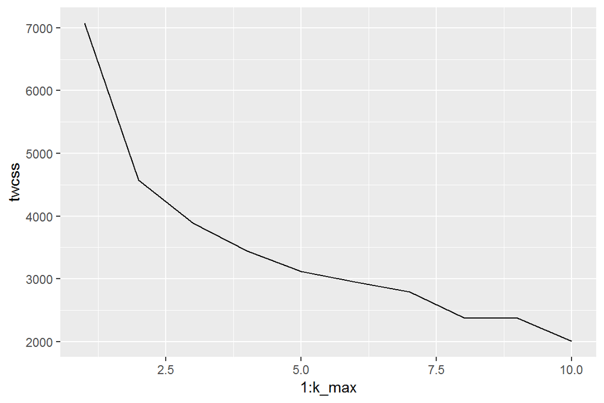

```r
library(MASS)
library(ggplot2)

set.seed(123)

k_max <- 10

twcss <- sapply(1:k_max, function(k){kmeans(b_scaled, k)$tot.withinss})

qplot(x = 1:k_max, y = twcss, geom = 'line')
```

Above the total within cluster sum of squares (twcss) illustrates what the optimal number of clusters by indicating the sharpest drop in the slope by that number. As seen in the graph, here it’s 2. Next we run the k-means algorithm and visualize the clusters by using the optimal number.

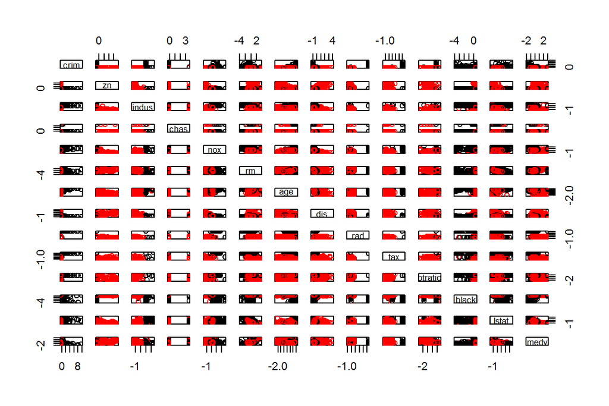

```r
km <-kmeans(b_scaled, centers = 2)

pairs(b_scaled, col = km$cluster)
```

Now the visualization of the data concentrate the results into two clusters. By the looks of it, it seems to be helpful and have more benefits than setbacks. No apparent cases of the clusters gravely overstepping each others boundaries are visible, which is a good sign.

*Didn’t have time for the bonus tasks.*

## #Week 5: Dimensionality reduction techniques

```r
library(dplyr)
library(GGally)
```

```r
library(ggplot2)
library(corrplot)
```

I have done my own wrangling, but to ensure compatibility and readability I import the external set.

```r
human <- read.table("http://s3.amazonaws.com/assets.datacamp.com/production/course_2218/datasets/human2.txt",
  sep=",",
  header=TRUE)
```

Next a graphical overview of the dataset and summaries of the variables.

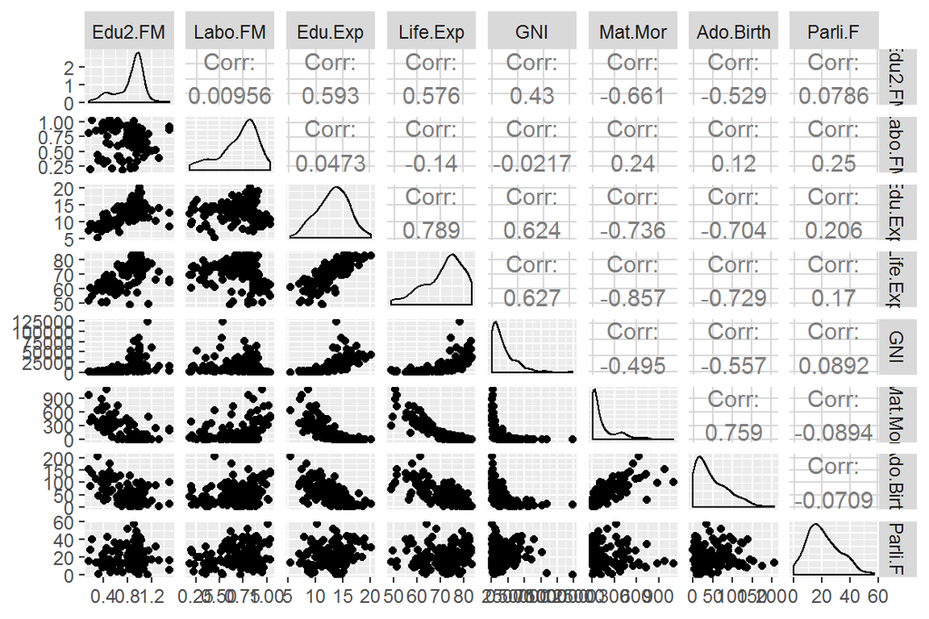

```r
vis <- ggpairs(human[,])
vis
```

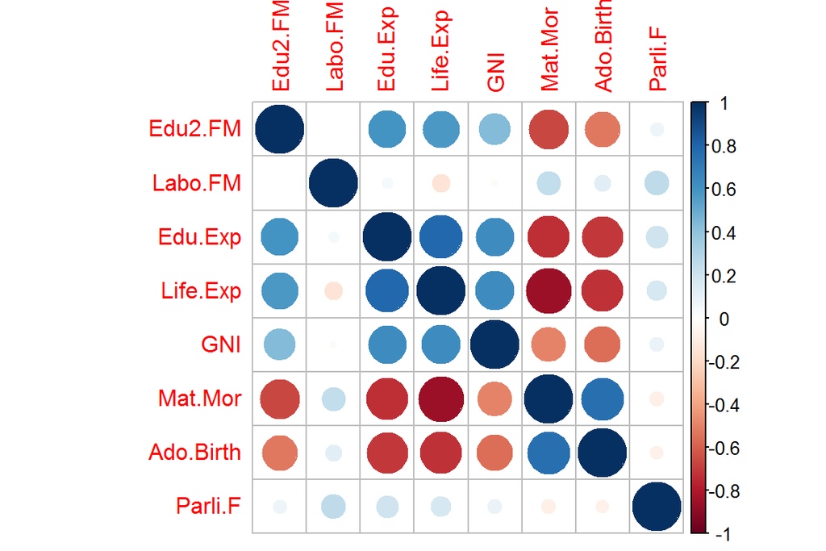

```r
cor(human) %>% corrplot()
```

```r
summary(human)
```

```
##     Edu2.FM          Labo.FM          Edu.Exp         Life.Exp
##  Min.   :0.1717   Min.   :0.1857   Min.   : 5.40   Min.   :49.00
##  1st Qu.:0.7264   1st Qu.:0.5984   1st Qu.:11.25   1st Qu.:66.30
##  Median :0.9375   Median :0.7535   Median :13.50   Median :74.20
##  Mean   :0.8529   Mean   :0.7074   Mean   :13.18   Mean   :71.65
##  3rd Qu.:0.9968   3rd Qu.:0.8535   3rd Qu.:15.20   3rd Qu.:77.25
##  Max.   :1.4967   Max.   :1.0380   Max.   :20.20   Max.   :83.50
##       GNI            Mat.Mor         Ado.Birth         Parli.F
##  Min.   :   581   Min.   :   1.0   Min.   :  0.60   Min.   : 0.00
##  1st Qu.:  4198   1st Qu.:  11.5   1st Qu.: 12.65   1st Qu.:12.40
##  Median : 12040   Median :  49.0   Median : 33.60   Median :19.30
##  Mean   : 17628   Mean   : 149.1   Mean   : 47.16   Mean   :20.91
##  3rd Qu.: 24512   3rd Qu.: 190.0   3rd Qu.: 71.95   3rd Qu.:27.95
##  Max.   :123124   Max.   :1100.0   Max.   :204.80   Max.   :57.50
```

In the colourful correlation plot we can see the relationships between the variables. Quite expected relations here, to be frank.

Maternal mortality and life expectancy have a quite strong negative correlation (larger red ball), ergo the higher the maternal mortality the lower the life expectancy in said country.

A positive correlation for maternal mortality is on the other hand adolescent births. That is, the occurrence of maternal mortality and teenage pregnancies tend to go hand in hand.

On a more positive note, a positive correlation between expected years of schooling and life expectancy is found in the plot. On the other hand, this doesn’t by any means show any causality. One could imagine that a person has more time to study simply because the person lives longer.

Something that shows a bit more promise for education are the pairs between expected education and maternal mortality and adolescent births. These pairs both correlate negatively. So there are clues of the societal and public health benefits of education, but again correlation doesn’t equal causation.

Next: perform a principal component analysis (PCA) on the dataset.

```r
pca_human <- prcomp(human)

summary(pca_human)
```

```
## Importance of components:
##                              PC1      PC2   PC3   PC4   PC5   PC6    PC7
## Standard deviation     1.854e+04 185.5219 25.19 11.45 3.766 1.566 0.1912
## Proportion of Variance 9.999e-01   0.0001  0.00  0.00 0.000 0.000 0.0000
## Cumulative Proportion  9.999e-01   1.0000  1.00  1.00 1.000 1.000 1.0000
##                           PC8
## Standard deviation     0.1591
## Proportion of Variance 0.0000
## Cumulative Proportion  1.0000
```

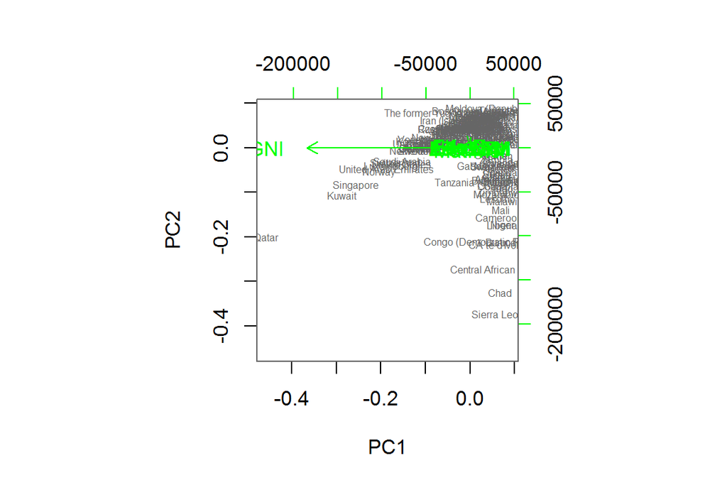

```r
biplot(pca_human, choices = 1:2, cex=c(0.5,1), col=c("grey40","green"))
```

As noted with regard to the distribution within the variables earlier, the differences are quite large between different countries. Therefore, when handling a holistic and global comparison like this one, the variability is all over the place. This is seen both in the summary above, where the figures are astronomical and in the biplot which doesn’t help at all in explaining this data. Analytically PCA might also assume that variables with larger variance are more important than dito with smaller variance, so therefore a PCA with unscaled data will probably be a poor one.

Because of these problems, we next standardize the data so that all observations become comparable with each other.

```r
human_std <- scale(human)

pca_human2 <- prcomp(human_std)

s <- summary(pca_human2)
s
```

```
## Importance of components:
##                           PC1    PC2     PC3     PC4     PC5     PC6
## Standard deviation     2.0708 1.1397 0.87505 0.77886 0.66196 0.53631
## Proportion of Variance 0.5361 0.1624 0.09571 0.07583 0.05477 0.03595
## Cumulative Proportion  0.5361 0.6984 0.79413 0.86996 0.92473 0.96069
##                            PC7     PC8
## Standard deviation     0.45900 0.32224
## Proportion of Variance 0.02634 0.01298
## Cumulative Proportion  0.98702 1.00000
```

```r
pca_pr <- round(1*s$importance[2, ], digits = 3)
pca_pr <- (pca_pr*100)
pca_pr
```

```
##  PC1  PC2  PC3  PC4  PC5  PC6  PC7  PC8
## 53.6 16.2  9.6  7.6  5.5  3.6  2.6  1.3
```

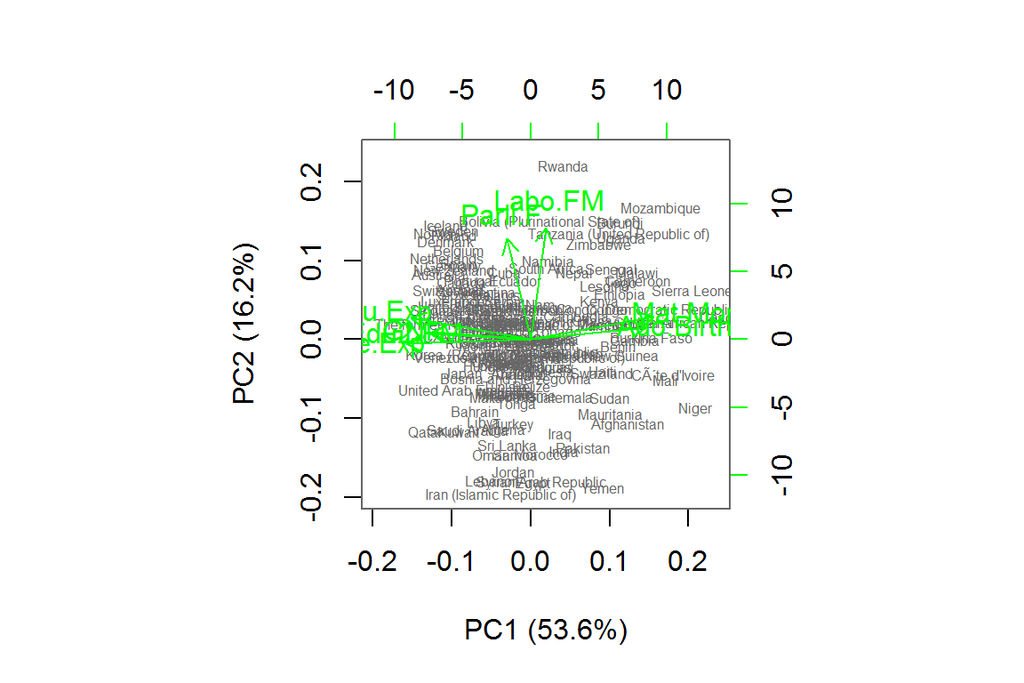

```r
pca_lab <- paste0(names(pca_pr), " (", pca_pr, "%)")

biplot(pca_human2, choices = 1:2, cex=c(0.5,1), col=c("grey40","green"), xlab = pca_lab[1], ylab = pca_lab[2])
```

I write my descriptions of the results here instead of in captions in the plot. Too much to say, wouldn’t fit in a caption.

Now we have much clearer results than in the previous plot, and we can see clear groupings of correlations basically possible to divide into three groups: 1. Wealth and quality of life, 2. Female empowerment and 3. Reproductive issues.

When reading a biplot, the smaller the angle between specific arrows are the larger the correlation between their corresponding variables are. So in group 1, we see that wealth (GNI), life expectancy, expected education and education among females all correlate quite well with each other. In group 2, countries with a larger share of female members of parliament also tend to have a larger female participation rate in the work force. And in group 3, as stated earlier, here again it is shown that maternal mortality and adolescent births often go hand in hand. Naturally, with these three groups having large angles between each other, they do not correlate that much with each other.

Moving on to the arrows and their relations to the PC1- and PC2-axis. Group 1 is negatively correlated with PC1 and mostly not correlated at all with PC2. Group 2 is positively correlated with PC2 and mostly not correlated at all with PC1. And group 3 is positively correlated with PC1 but mostly not correlated at all with PC2.

Something worth mentioning that doesn’t speak in favor of this analysis is its lack of variability coverage. The PC1 and PC2 together cover less than 70 percent of the variability (visible both in the axis and in the summary above: “cumulative proportion”). That means less than 70 percent of the variability in the data here can be explained with this analysis. Might be though that that is a fairly okay coverage, considering the massive variation in the data and multitude of outliers.

Moving on to MCA and the tea dataset. First we load the dataset and explore the structure and dimensions.

```r
library(FactoMineR)
library(dplyr)
library(ggplot2)
library(tidyr)

tea <- read.table("http://factominer.free.fr/course/donnees/data_MCA_Tea.csv",
                  sep=";",
                  header=TRUE)
dim(tea)
```

```
## [1] 300  36
```

```r
str(tea)
```

```
## 'data.frame':    300 obs. of  36 variables:
##  $ breakfast       : Factor w/ 2 levels "breakfast","Not.breakfast": 1 1 2 2 1 2 1 2 1 1 ...
##  $ tea.time        : Factor w/ 2 levels "Not.tea time",..: 1 1 2 1 1 1 2 2 2 1 ...
##  $ evening         : Factor w/ 2 levels "evening","Not.evening": 2 2 1 2 1 2 2 1 2 1 ...
##  $ lunch           : Factor w/ 2 levels "lunch","Not.lunch": 2 2 2 2 2 2 2 2 2 2 ...
##  $ dinner          : Factor w/ 2 levels "dinner","Not.dinner": 2 2 1 1 2 1 2 2 2 2 ...
##  $ always          : Factor w/ 2 levels "always","Not.always": 2 2 2 2 1 2 2 2 2 2 ...
##  $ home            : Factor w/ 2 levels "home","Not.home": 1 1 1 1 1 1 1 1 1 1 ...
##  $ work            : Factor w/ 2 levels "Not.work","work": 1 1 2 1 1 1 1 1 1 1 ...
##  $ tearoom         : Factor w/ 2 levels "Not.tearoom",..: 1 1 1 1 1 1 1 1 1 2 ...
##  $ friends         : Factor w/ 2 levels "friends","Not.friends": 2 2 1 2 2 2 1 2 2 2 ...
##  $ resto           : Factor w/ 2 levels "Not.resto","resto": 1 1 2 1 1 1 1 1 1 1 ...
##  $ pub             : Factor w/ 2 levels "Not.pub","pub": 1 1 1 1 1 1 1 1 1 1 ...
##  $ Tea             : Factor w/ 3 levels "black","Earl Grey",..: 1 1 2 2 2 2 2 1 2 1 ...
##  $ How             : Factor w/ 4 levels "alone","lemon",..: 1 3 1 1 1 1 1 3 3 1 ...
```

[output cut: 22 more lines]

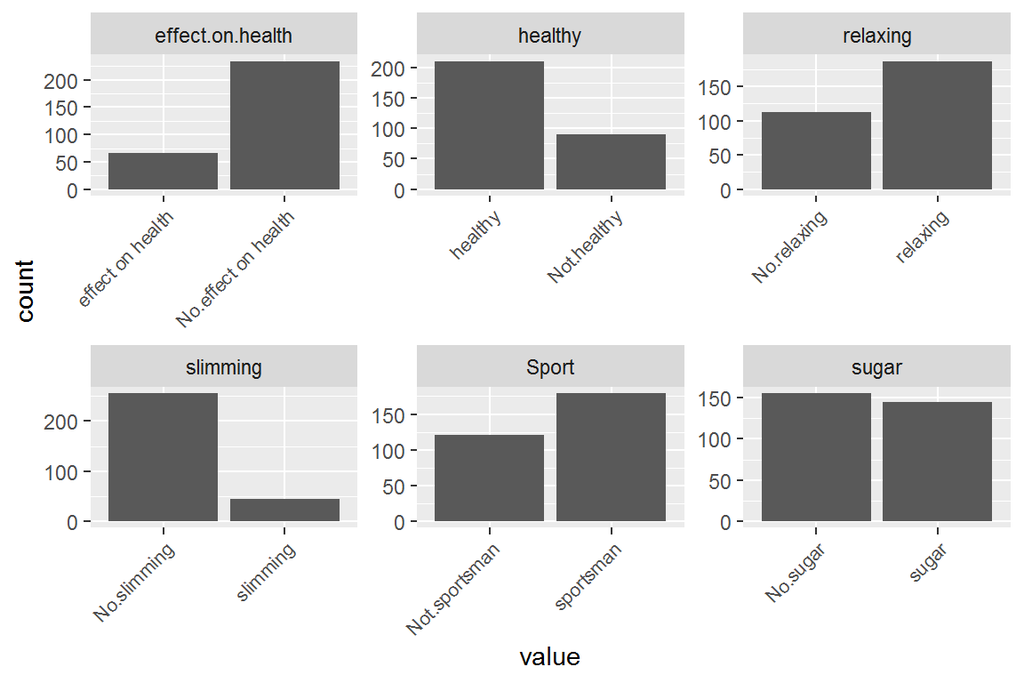

```r
keep_columns <- c("Sport", "slimming", "relaxing", "healthy", "sugar", "effect.on.health")

tea_time <- select(tea, one_of(keep_columns))

gather(tea_time) %>% ggplot(aes(value)) + facet_wrap("key", scales = "free") + geom_bar() + theme(axis.text.x = element_text(angle = 45, hjust = 1, size = 8))
```

The tea dataset is a questionnaire with 36 questions regarding tea consumption. 300 individuals have participated in the questionnaire. The dimensions are way too big to visualize neatly and understandibly in one plot. Above instead a smaller sample.

Next we move on to MCA. We’ll utilize the same columns as plotted above.

```r
mca <- MCA(tea_time, graph = FALSE)
summary(mca)
```

```
##
## Call:
## MCA(X = tea_time, graph = FALSE)
##
##
## Eigenvalues
##                        Dim.1   Dim.2   Dim.3   Dim.4   Dim.5   Dim.6
## Variance               0.231   0.196   0.176   0.162   0.139   0.098
## % of var.             23.073  19.550  17.558  16.158  13.856   9.804
## Cumulative % of var.  23.073  42.624  60.182  76.340  90.196 100.000
##
## Individuals (the 10 first)
##                  Dim.1    ctr   cos2    Dim.2    ctr   cos2    Dim.3
## 1             | -0.081  0.009  0.009 | -0.218  0.081  0.067 | -0.264
## 2             | -0.129  0.024  0.024 |  0.265  0.120  0.102 | -0.400
## 3             | -0.405  0.237  0.318 | -0.117  0.023  0.026 | -0.056
## 4             | -0.365  0.192  0.198 | -0.254  0.110  0.096 | -0.166
## 5             |  0.209  0.063  0.052 | -0.284  0.138  0.097 | -0.061
## 6             | -0.405  0.237  0.318 | -0.117  0.023  0.026 | -0.056
## 7             | -0.405  0.237  0.318 | -0.117  0.023  0.026 | -0.056
## 8             | -0.405  0.237  0.318 | -0.117  0.023  0.026 | -0.056
## 9             |  0.209  0.063  0.052 | -0.284  0.138  0.097 | -0.061
## 10            | -0.414  0.247  0.263 |  0.230  0.090  0.081 | -0.302
##                  ctr   cos2
## 1              0.133  0.098 |
## 2              0.304  0.232 |
## 3              0.006  0.006 |
## 4              0.052  0.041 |
## 5              0.007  0.004 |
## 6              0.006  0.006 |
## 7              0.006  0.006 |
## 8              0.006  0.006 |
## 9              0.007  0.004 |
## 10             0.173  0.140 |
##
## Categories (the 10 first)
##                   Dim.1     ctr    cos2  v.test     Dim.2     ctr    cos2
## Not.sportsman |  -0.014   0.006   0.000  -0.201 |   0.548  10.337   0.203
## sportsman     |   0.010   0.004   0.000   0.201 |  -0.371   6.988   0.203
## No.slimming   |   0.101   0.632   0.058   4.175 |  -0.204   3.021   0.236
```

[output cut: 12 more lines]

```
## No.relaxing     8.494 |  -0.539  10.398   0.176  -7.249 |
## relaxing       -8.494 |   0.326   6.283   0.176   7.249 |
## healthy         3.521 |   0.003   0.001   0.000   0.087 |
## Not.healthy    -3.521 |  -0.008   0.002   0.000  -0.087 |
## No.sugar       11.083 |  -0.165   1.343   0.029  -2.958 |
## sugar         -11.083 |   0.177   1.435   0.029   2.958 |
##
## Categorical variables (eta2)
##                    Dim.1 Dim.2 Dim.3
## Sport            | 0.000 0.203 0.092 |
## slimming         | 0.058 0.236 0.546 |
## relaxing         | 0.149 0.241 0.176 |
## healthy          | 0.659 0.041 0.000 |
## sugar            | 0.005 0.411 0.029 |
## effect.on.health | 0.514 0.040 0.210 |
```

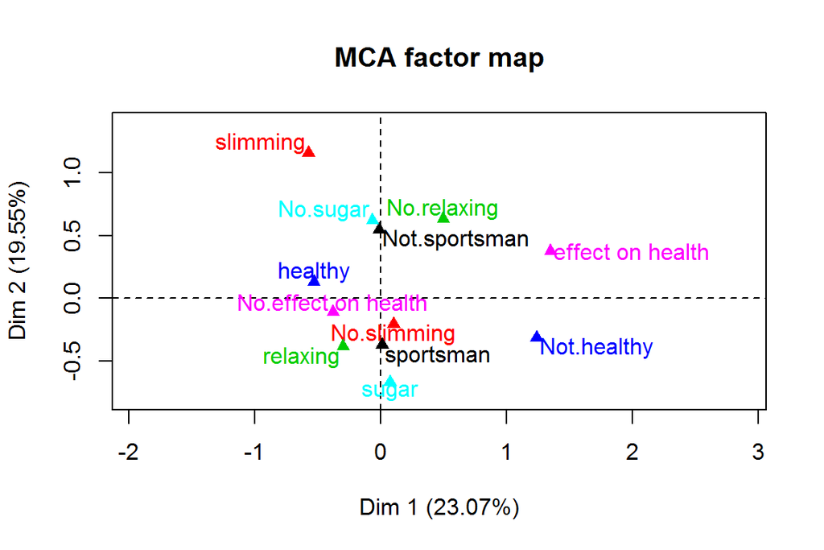

```r
plot(mca, invisible=c("ind"), habillage="quali")
```

In the summary the squared correlation for the categorical variables are not even close to 1, so there’s no bond worth mentioning between the variables and the dimensions.

In the biplot some interesting similarities between variables is are shown. Somewhat peculiar for example that no sugar and not sportsman are close to each other, and the opposites sportsman and sugar also are close together. Also weird that no effect on health and healthy can be that close to each other.

## #Week 6: Analysis of longitudinal data

Import all necessary libraries.

```r
library(dplyr)
library(tidyr)
library(ggplot2)
```

Import the RATS data and display it.

```r
RATS <- read.table("https://raw.githubusercontent.com/KimmoVehkalahti/MABS/master/Examples/data/rats.txt", sep='\t', header=TRUE)
RATS
```

```
##    ID Group WD1 WD8 WD15 WD22 WD29 WD36 WD43 WD44 WD50 WD57 WD64
## 1   1     1 240 250  255  260  262  258  266  266  265  272  278
## 2   2     1 225 230  230  232  240  240  243  244  238  247  245
## 3   3     1 245 250  250  255  262  265  267  267  264  268  269
## 4   4     1 260 255  255  265  265  268  270  272  274  273  275
## 5   5     1 255 260  255  270  270  273  274  273  276  278  280
## 6   6     1 260 265  270  275  275  277  278  278  284  279  281
## 7   7     1 275 275  260  270  273  274  276  271  282  281  284
## 8   8     1 245 255  260  268  270  265  265  267  273  274  278
## 9   9     2 410 415  425  428  438  443  442  446  456  468  478
## 10 10     2 405 420  430  440  448  460  458  464  475  484  496
## 11 11     2 445 445  450  452  455  455  451  450  462  466  472
## 12 12     2 555 560  565  580  590  597  595  595  612  618  628
## 13 13     3 470 465  475  485  487  493  493  504  507  518  525
## 14 14     3 535 525  530  533  535  540  525  530  543  544  559
## 15 15     3 520 525  530  540  543  546  538  544  553  555  548
## 16 16     3 510 510  520  515  530  538  535  542  550  553  569
```

The set comprises of 16 rats divided into 3 different groups, depending on the diet they were put on. The table shows the weight development for each rat (each figure is weight at that time in grams).

Next we draw the plot for this set, differentiating between the diet groups. But before that we need to convert the set into long form.

```r
RATS$ID <- factor(RATS$ID)
RATS$Group <- factor(RATS$Group)

RATSL <- RATS %>% gather(key = WD, value = Weight, -ID, -Group) %>% mutate(Time = as.integer(substr(WD, 3, 4)))
```

And now we draw the plot, with the set in long form.

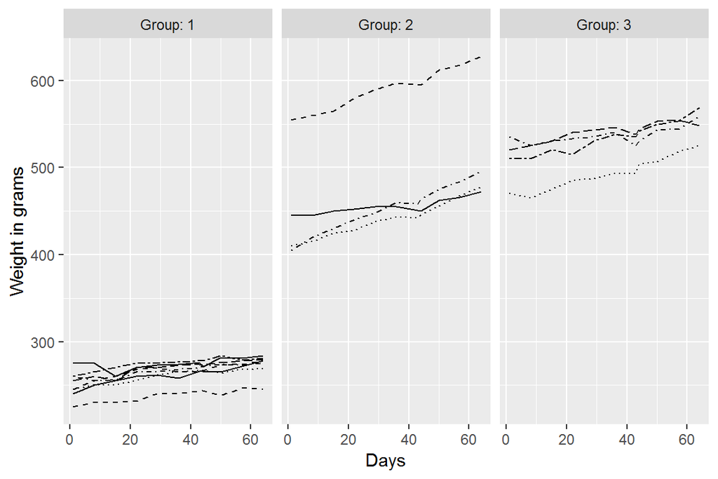

```r
ggplot(RATSL, aes(x = Time, y = Weight, linetype = ID)) +
  geom_line() +
  xlab("Days") +
  ylab("Weight in grams") +
  scale_linetype_manual(values = rep(1:10, times=4)) +
  facet_grid(. ~ Group, labeller = label_both) +
  theme(legend.position = "none")
```

As we can see, there individuals start out with vastly different weights. In general the rats in the first group weigh half as much as the ones in 2 and 3. The rats in group 2 clearly gain the most weight, group 3 almost as much, but the ones in 1 gain almost no weight.

This following of progress in individuals over time, also known as tracking, can be done better with standardized data. So next, we standardize the rat data and plot it.

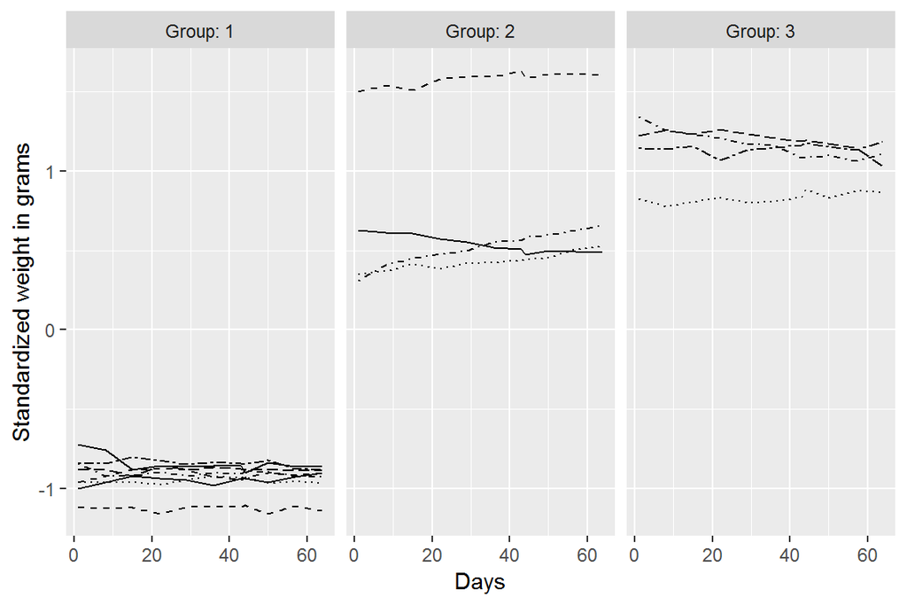

```r
RATSL <- RATSL %>%
  group_by(Time) %>%
  mutate(stdw = scale(Weight)) %>%
  ungroup()

ggplot(RATSL, aes(x = Time, y = stdw, linetype = ID)) +
  geom_line() +
  xlab("Days") +
  ylab("Standardized weight in grams") +
  scale_linetype_manual(values = rep(1:10, times=4)) +
  facet_grid(. ~ Group, labeller = label_both) +
  theme(legend.position = "none")
```

Now that we’ve subtracted the weight mean from the observations and divided by the standard deviation a completely different plot presents itself. By creating average profiles of each group, this method can iron out some larger differences that cause the plot to skew. In the difference here between the first and the second plot, there’s some indication of perhaps an outlier or something similar, that throws the first plot off balance. The difference is stark especially when looking at the coefficients of the lines, with more or less everyone going from weight gain in the first plot to neutral weight or even weight loss in the second plot.

As mentioned in the MABS-book, boxplot-like (summary graphs) plots can be good to spot for example potential outliers. So next, we move on to that.

```r
n <- RATSL$Time %>% unique() %>% length()

RATSS <- RATSL %>%
  group_by(Group, Time) %>%
  summarise(mean = mean(Weight), se = (sd(Weight)/sqrt(n))) %>%
  ungroup()

glimpse(RATSS)
```

```
## Observations: 33
## Variables: 4
## $ Group <fct> 1, 1, 1, 1, 1, 1, 1, 1, 1, 1, 1, 2, 2, 2, 2, 2, 2, 2, 2,...
## $ Time  <int> 1, 8, 15, 22, 29, 36, 43, 44, 50, 57, 64, 1, 8, 15, 22, ...
## $ mean  <dbl> 250.625, 255.000, 254.375, 261.875, 264.625, 265.000, 26...
## $ se    <dbl> 4.589478, 3.947710, 3.460116, 4.100800, 3.333956, 3.5529...
```

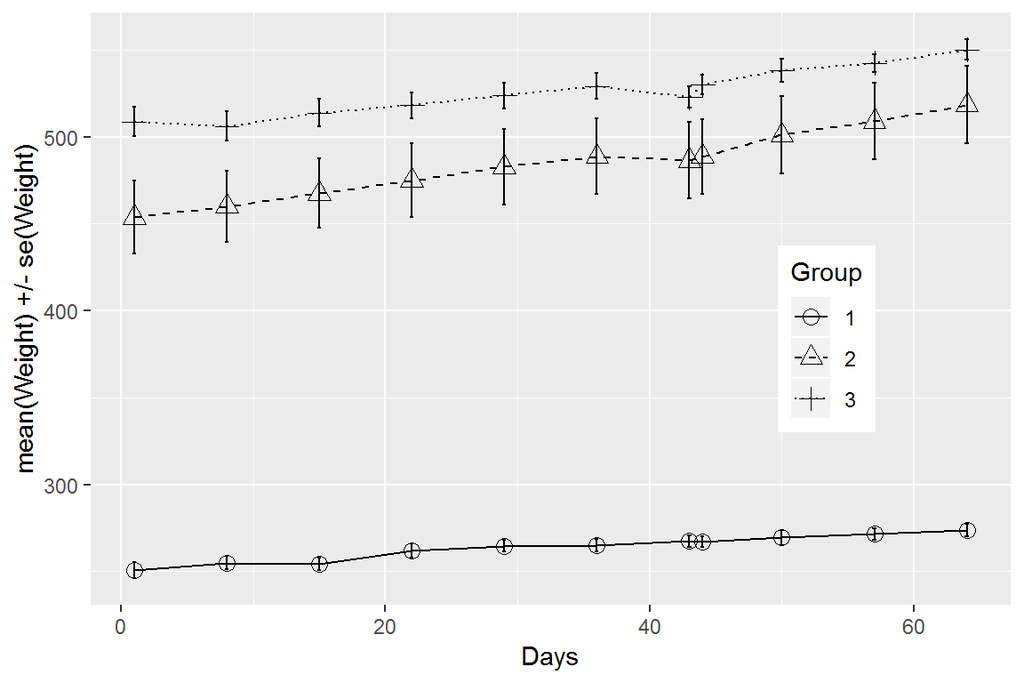

```r
ggplot(RATSS, aes(x = Time, y = mean, linetype = Group, shape = Group)) +
  geom_line() +
  scale_linetype_manual(values = c(1,2,3)) +
  geom_point(size=3) +
  scale_shape_manual(values = c(1,2,3)) +
  geom_errorbar(aes(ymin=mean-se, ymax=mean+se, linetype="1"), width=0.3) +
  theme(legend.position = c(0.8,0.45)) +
  scale_y_continuous(name = "mean(Weight) +/- se(Weight)") +
  scale_x_continuous(name = "Days")
```

Here we use mean weight profiles again with standard errors subtracted from them, which is quite indicative of the lines behaving this coherently. Worth noting though that here again the general trend has shifted towards weight gain.

For the next boxplot I’ve wasted hours on trying to get it to work correctly, but I just can’t get the three groups to appear grouped on each x-value. Below my failed work in progress.

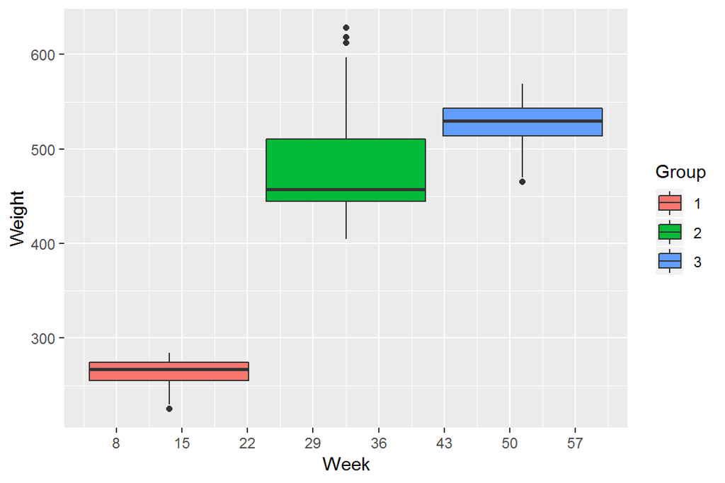

```r
ggplot(RATSL, aes(Time,Weight)) +
  geom_boxplot(aes(fill=Group)) +
  scale_x_continuous(name = "Week", breaks = seq(1, 70, 7))
```

Next we create boxplots with weight means over the course of the handful of weeks of the experiment. We exclude the first week by filtering (Time > 1).

```r
RATSLS <- RATSL %>%
  filter(Time > 1) %>%
  group_by(Group, ID) %>%
  summarise( mean=mean(Weight) ) %>%
  ungroup()

glimpse(RATSLS)
```

```
## Observations: 16
## Variables: 3
## $ Group <fct> 1, 1, 1, 1, 1, 1, 1, 1, 2, 2, 2, 2, 3, 3, 3, 3
## $ ID    <fct> 1, 2, 3, 4, 5, 6, 7, 8, 9, 10, 11, 12, 13, 14, 15, 16
## $ mean  <dbl> 263.2, 238.9, 261.7, 267.2, 270.9, 276.2, 274.6, 267.5, ...
```

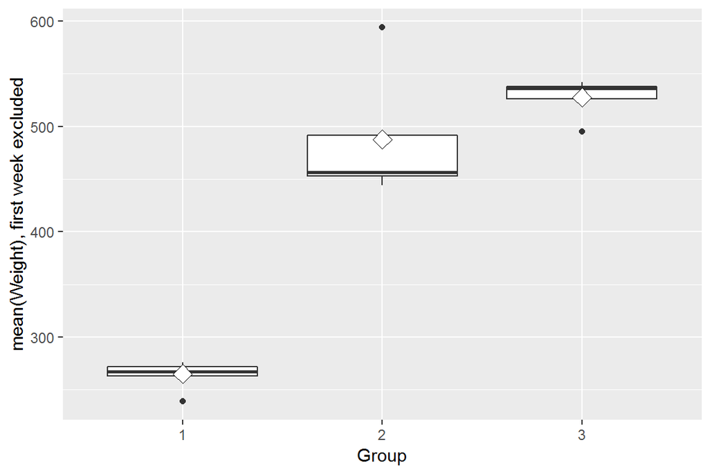

```r
ggplot(RATSLS, aes(x = Group, y = mean)) +
  geom_boxplot() +
  stat_summary(fun.y = "mean", geom = "point", shape=23, size=4, fill = "white") +
  scale_y_continuous(name = "mean(Weight), first week excluded")
```

```r
RATSLS <- RATSL %>%
  filter(Time > 1, Weight < 550) %>%
  group_by(Group, ID) %>%
  summarise( mean=mean(Weight) ) %>%
  ungroup()

glimpse(RATSLS)
```

```
## Observations: 15
## Variables: 3
## $ Group <fct> 1, 1, 1, 1, 1, 1, 1, 1, 2, 2, 2, 3, 3, 3, 3
## $ ID    <fct> 1, 2, 3, 4, 5, 6, 7, 8, 9, 10, 11, 13, 14, 15, 16
## $ mean  <dbl> 263.2000, 238.9000, 261.7000, 267.2000, 270.9000, 276.20...
```

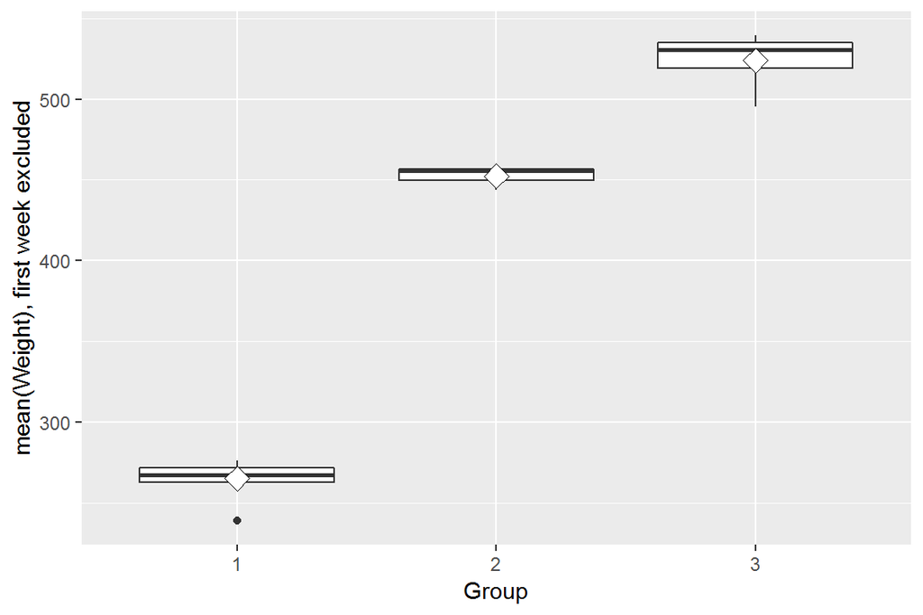

```r
ggplot(RATSLS, aes(x = Group, y = mean)) +
  geom_boxplot() +
  stat_summary(fun.y = "mean", geom = "point", shape=23, size=4, fill = "white") +
  scale_y_continuous(name = "mean(Weight), first week excluded")
```

As the plot shows, removing that outlier made the span in Group 2 significantly more coherent. With the outlier the second and third quartile spanned from around 450 grams to almost 500. But without the outlier, the group is tightly gathered around 450 grams. The visuals of group 3 shifted a bit, but that’s just because the scale of the y-axis shifted due to the discarding of the high value in group 2.

On to t-tests.